# Algorithms

## Pseudocode

Pseudocode is description of steps in an algorithm. The code does not follow any specific programming language conventions. The idea is that a person familiar with pseudocode should be able to translate the algorithm into a function in the programming language of choice. Many articles in statistics, computer sicence, and machine learning have algorithms described in a pseudocode. As such you are expected to be able to translate this into an R-code.

Here is an example of a simple pseudo-code for an algorithm that computes the following sum
$$\sum_{i=1}^n f(x_i)$$

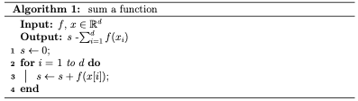

Below we can translate it into R-code:

```
Alg1 <- function(f, x){
  s = 0
  for(i in 1:length(x)){
    s = s + f(x[i])
  }
  return(s)
}
```

We can that for instance compute
$$\sum_{i=1}^{10} i^2$$
We can solve this using the sum algorithm for the two arguments $f(x)=x^2$ and $x=[1,2,3,4,5,6,7,8,9,10]$. In R we get

[output not shown]

As we are working with statistics we will often see random number in the pseudo code. Below is an algorithm that a uniform random number to produce sample of an [exponential distribution](https://en.wikipedia.org/wiki/Exponential_distribution) using [the inverse transform sampling](https://en.wikipedia.org/wiki/Inverse_transform_sampling):

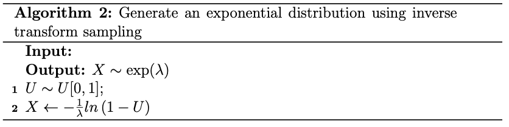

Which in R would be

```
Alg2 <- function(lambda){
  U <- runif(1)
  X <- - 1/lambda * log(1-U)
  return(X)
}
```

```
set.seed(1)
lambda=2
X = Alg2(lambda)
```

The inverse of the CDF used in inverse transform sampling is the quantile function, which in R for exponential distribution is denoted `qexp` so we can write a more general method to sample as

```
inverse.sample <- function(Finv){
  U <- runif(1)
  X <- Finv(U)
  return(X)
}
```

Again to generate from an exponential distribution we do

```
set.seed(1)
lambda = 2
X = inverse.sample(function(x){qexp(x, lambda)})
```